# Basic Linux Tutorial

Author

Dr Laura Dean

[figure not shown]

### How to use this tutorial

This tutorial gives some basic examples of Linux commands that will be useful to you in navigating the HPC environment. These examples are designed to be run from your terminal, on the HPC so you will need to connect to the VPN and login to the HPC before testing the commands below.

Code examples are given in code blocks e.g.

```bash
some code
```

Where you see these blocks you can use the copy button in the top right hand corner of the box to copy the code to paste into your terminal. In some cases you will need to change the code slightly to match your own file or directory names or username, rather than those given in the examples.

It’s also a good idea to practice typing the commands into your terminal because this will help you to remember them.

### Finding where you are

To find out where you currently are on the filesystem you can use the `pwd` command, which stands for **P**rint **W**orking **D**irectory:

```bash
pwd
```

This will print the absolute path to the directory you are in to the terminal. Example output:

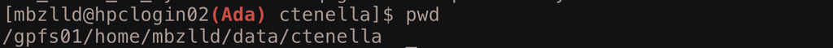

When you first login to the HPC, you are always in your own home directory so when you type `pwd` you will see the path `gpfs01/home/` followed by your own university username.

### Listing the contents of your working directory

To list the contents of the directory you are in we use the `ls` command (short for **L**i**s**t):

```bash
ls
```

This will print the names of all the directories and files within your working directory.

Example output:

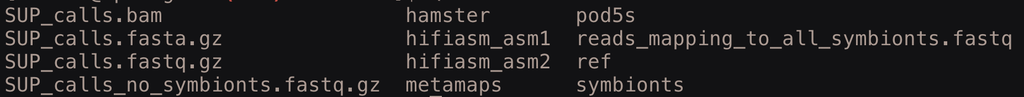

You may not have many (or any visible?) files or directories in your home directory to begin with.

Let’s start by creating some!

### Creating files

To create a new, empty file, we can use the `touch` command.

Create an empty new file called `my_file.txt`:

```bash
touch my_file.txt
```

Now lets try the `ls` command again:

```bash
ls
```

You should now see the file `my_file.txt` that you just created.

### More about `ls`

The output above is good, but it’s not really giving us any information about the files / directories. You can add some options to the list command to print more information using flags:

(l = long, t = time, r = reverse, h = human readable)

```bash
ls -ltrh
```

This will list all the files and directories in your current working directory in ‘long’ format (giving you more information), ordered by the time the files were last modified, by default this would show most recently modified files at the top but if you have a lot of files this can mean they aren’t easy to see so here we reverse that order so the most recently modified files are at the bottom. The h means that the file size is printed in a more readable format (K - kb, M - mb, G - gb etc rather than just bytes).

Here is an example output of `ls -ltrh` with an explanation of the information the command gives you about your files and directories:

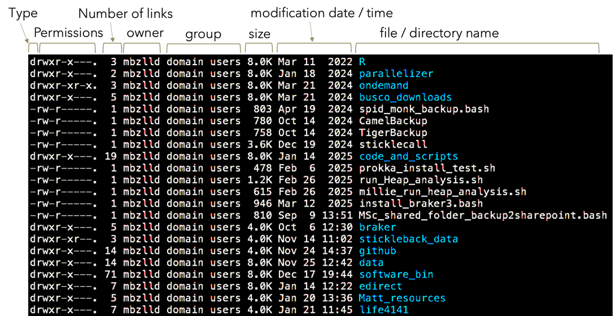

Have a go at running the `ls -ltrh` command in your terminal. Now you can see a bit more information about the file you just made.

There are many more options available for the `ls` command. Try having a look at some of the other options using the manual (HINT: you can use the space bar to scroll through the manual and the q button to exit the manual when you’ve finished looking at it):

```bash
man ls
```

### Writing content to files

We can use the `echo` command to print text or information that we give it. The classic example:

```bash
echo "Hello World"
```

Will print the text you give it back to you in the terminal. If instead, we want to save the output of the echo command to a file we use the redirect arrow to send the output to a new file. Here we will call it `example.txt`:

IMPORTANT: This will overwrite anything that in example.txt if it already exists so use redirect with caution!

```bash
echo "This is some text that we want to put inside our file" > example.txt
```

### Viewing file contents

Now we might want to look inside the file we just created to make sure that it contains the text that we intended. There are many different ways that you can do this. If the contents of the file is small, you can print the contents to the screen using the cat command (cat actually stands for con**CAT**enate, but in its simplest form it will print file contents):

```bash
cat example.txt
```

If the file is very big, it is difficult to view it using cat and commands that open the file for browsing are better. An example is the `less` command. Try viewing your `example.txt` file using the `less` command:

HINT: when you are finished you can exit the less file view by typing `q`

```bash
less example.txt
```

### File manipulation

Lets create some more files to work with. This time we will create three files, each with some text in:

```bash
echo "This is the first part of our file" > File_1.txt
echo "This is the middle part" > File_2.txt
echo "This is the final part of our file" > File_3.txt
```

Now what if we wanted to make a new file that contains all of the contents of `File_1.txt`, `File_2.txt` and `File_3.txt`? We can use the `cat` command again but instead of printing the output to the screen we can redirect it to a new file:

```bash
cat File_1.txt File_2.txt File_3.txt > Big_file.txt
```

So far we have used the single `>` to redirect output to files. This OVERWRITES anything that was previously in the file that we directed the output to. What if we wanted to append something to the end of another file? Then we use the double chevron `>>`, which will add to what is there rather than overwriting it.

Example:

```bash
echo "This is the very final, final part of our file" >> Big_file.txt
```

Have a look at the contents of `Big_file.txt` using `cat` or `less`

```bash
cat Big_file.txt
```

OR

```bash
less Big_file.txt
```

(remember `q` gets you out of the file when you use `less`)

### Deleting files

To remove files in Linux, we use the `rm` command, which stands for **R**e**M**ove.

It is important to remember that unlike on Windows or Mac operating systems, in Linux once you delete a file, there is no recycle bin and no recovery. Once it is gone, its gone and you can’t get it back, so use with caution!

Lets remove our `File_1.txt` and then run the `ls` command to check it has gone:

```bash
rm File_1.txt
ls -ltrh
```

### Copying files

To copy a file or directory we can use the `cp` command. They syntax for this command is command source destination. Lets make a copy of `Big_file.txt`, called `Big_file2.txt` :

```bash
cp Big_file.txt Big_file2.txt
```

### Making and deleting directories

To make a directory, we use the command `mkdir`, short for **M**a**K**e **DIR**ectory. Lets make a new directory called `scripts`:

```bash
mkdir scripts
```

### Moving around

To change directory we use the command `cd` (short for **C**hange **D**irectory) followed by the place we want to move to:

```bash
cd scripts
```

now try the `pwd` (print working directory) command again to check where you are:

```bash
pwd
```

You should see that you are now inside the `scripts` directory.

Lets make a sub-directory inside `scripts`:

```bash
mkdir python_scripts
```

Lets check that we can see the new directory we made using `ls`:

```bash
ls -ltrh
```

If we want to move up one parent directory we can use the shorthand `..`:

```bash
cd ..
```

Now let’s check where we are again:

```bash
pwd
```

You should be back in your home directory (one above where we were, inside `scripts`.

Let’s practice using tab auto-completion to move to `scripts/python_scripts` type the code below and press tab:

```bash
cd s
```

This should fill in the `scripts/` part of the path for you. Now type the first letter of the `python_scripts` directory `p` and press tab again.

This should have auto-completed the rest of the path for you so what you now have at your command prompt is `cd scripts/python_scripts`. Press enter to run the command. Let’s check we have moved to the right place by running `pwd` again:

```bash
pwd
```

now if we want to move back to our home directory there are a few ways we can do that. First we could use the `..` notation. To move more than one directory in the same command we can separate each `..` (which stands for one level of parent directory) with `/` :

```bash
cd ../..
```

Second we can use the special character `~`, which is shorthand for your home directory:

```bash
cd ~
```

Finally, we can use the `cd` command with no arguments as this will also by default take you back to your home directory.

```bash
cd
```

#### Absolute and relative paths

If you use the `cd` command with an absolute path (one that starts from the root `/`) this will take you to that directory from anywhere on the HPC. For example, the absolute path to your python_scripts directory is `gpfs01/home/` then your university username, then `/scripts/python_scripts`. Try using the absolute path with the `cd` command (REMBEMBER: you will need to replace USERNAME with your own university username:

```bash
cd /gpfs01/home/USERNAME/scripts/python_scripts
```

Absolute paths are useful, but also long. It can often be quicker to use relative paths with the `cd` command. Remember, a relative path is relative to where you are now and so will only work if you are in the correct directory when you run it. For example, lets make sure we are in our home directory with `cd ~` and then move to python_scripts using the relative path:

```bash
cd ~
cd scripts/python_scripts
```

### Moving or renaming files

Renaming files in Linux is done by moving them, so moving a file to a different location and renaming one are both carried out with the same `mv` command.

First lets try renaming our file `Big_file2.txt` to `New_Big_file2.txt` :

```bash
mv Big_file2.txt New_Big_file2.txt
```

Now lets check our file has been renamed correctly using `ls`:

```bash
ls -ltrh
```

Now lets try moving it to our `scripts` directory:

```bash
mv New_Big_file2.txt scripts/
```

lets check it has gone from our `home` directory, and then check it is in our `scripts` directory:

```bash
ls -ltrh
ls -ltrh scripts
```

#### Viewing directory and sub-directory contents

Sometimes it can be useful to get an overview of all files and sub-directories within a directory. For this we can use the `tree` command. Lets move back to our home directory and then run the `tree` command on the `scripts` directory:

```bash
cd
tree scripts
```

This will print a nice overview of the structure of your directory. Here is an example of the output of the `tree` command with a directory that contains more files than your `scripts` directory:

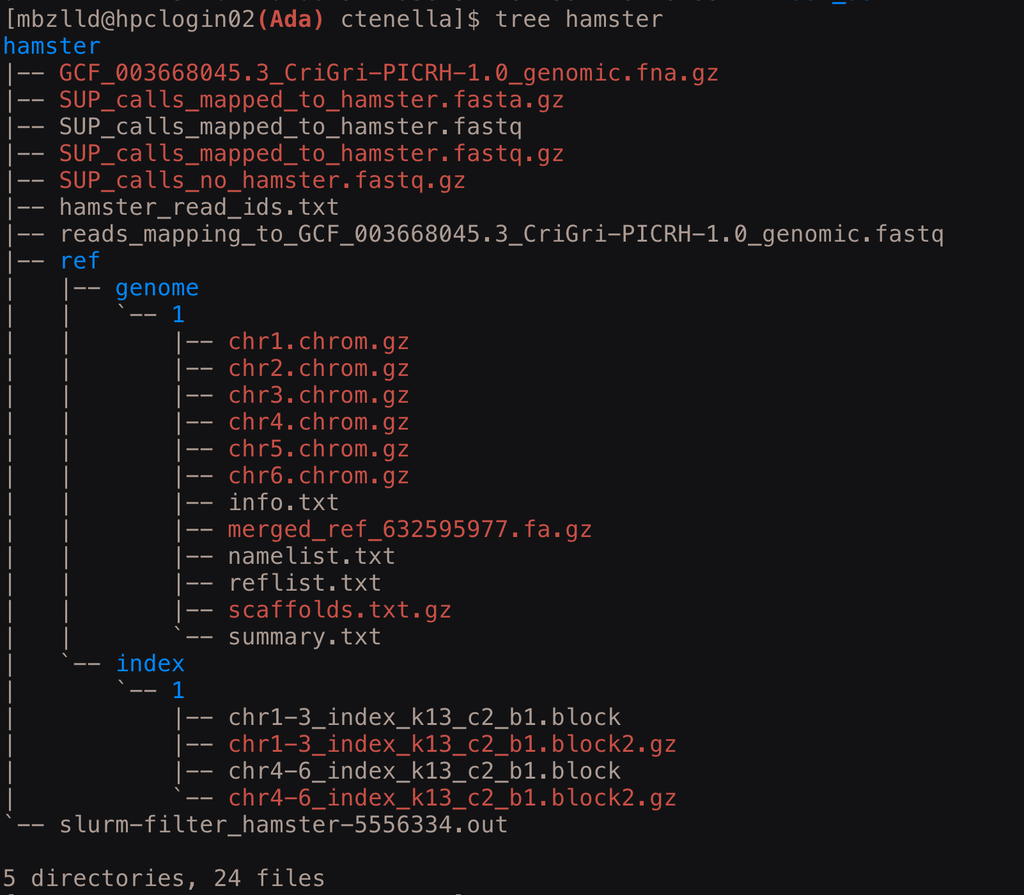